# Básico

Óscar García Hernández

23 de octubre de 2018

# ¿Qué es esto?

Este documento tiene la intención de ser un a *GUÍA SUPER BÁSICA* introductoria al lenguaje de programación en R.

# Interfaz Rstudio

Dentro de la interfaz de Rstudio hay varias secciones. Principalmente podemos definir 4.

- La parte destinada a Script’s. Donde construiremos nuestro código.
- Una consola, donde ejecutamos comandos.
- Enviroment: donde se guardan las variable que definimos.
- Ventana multiusos donde se presentan las gráficas que elaboramos, aparecen las ayudas, los archivos de la carpeta de trabajo etc.

[figure not shown]

Si no te aparece la ventan de script’s es porque aun no has creado uno.

[figure not shown]

Una vez que ya nos hemos creado el script podemos empezar a ver cositas básicas para programar.

# Vectores

Es importante saber crear y tratar con vectores. En R los vectores se crean usando el siguiente comando.

```r
#Se usa c(), y entre los parentesis ponemos los elementos del vector

c(1,2,3,4,5,6,7,8,9,10)
```

```
##  [1]  1  2  3  4  5  6  7  8  9 10
```

Si quiero guardar mi vector le pondré un nombre a la variable y se guardará en el enviroment.

```r
vector_1 <- c(1,2,3,4,5,6,7,8,9,10)
```

> Nótese que en R el símbolo “**=**” se escribe como “**<-**”

Tambien podemos crear vectores que contengan palabras o palabras y numeros.

```r
#Las palabras se definen entre comillas
vector_2 <- c(1,"mono",3,4,"platano",6,7,8,"pato",10)
```

Si quiero acceder a un valor específico de mi vector usare corchetes “[]”

```r
#Accedo al elemento 2 del vector
vector_2[2]
```

```
## [1] "mono"
```

Incluso puedo acceder a varios valores a la vez.

```r
#Accedo al valor 2 y al valor 6 del vector.
vector_2[c(2,6)]
```

```
## [1] "mono" "6"
```

Nótese que para buscar el valor 2 y 6 del vector, debo introducir un vector. Si lo hago sin definir un vector da error, porque interpreta que estamos buscando el valor de la fila 2 y la columna 6, y nuestro vector solamente tienen una dimensión.

```r
vector_2[2,6]
```

```
## Error in vector_2[2, 6]: número incorreto de dimensiones
```

**Es importante interiorizar cuando se usan paréntesis y cuando se usan corchetes. Por norma general podemos decir que los corchetes nos sirven para buscar información dentro de vectores, matrices, tablas, etc.**

A la hora de crear vectores se pueden usar otros atajos. Por ejemplo:

```r
1:10
```

```
##  [1]  1  2  3  4  5  6  7  8  9 10
```

Nos crean un vector con un intervalo de 1.

Si queremos variar el intervalo del vector podemos usar el comando *seq*.

```r
#seq(numero_inicial, numero_final, intervalo)
a<-seq(1,10,0.03)
```

```
##   [1]  1.00  1.03  1.06  1.09  1.12  1.15  1.18  1.21  1.24  1.27  1.30
##  [12]  1.33  1.36  1.39  1.42  1.45  1.48  1.51  1.54  1.57  1.60  1.63
##  [23]  1.66  1.69  1.72  1.75  1.78  1.81  1.84  1.87  1.90  1.93  1.96
##  [34]  1.99  2.02  2.05  2.08  2.11  2.14  2.17  2.20  2.23  2.26  2.29
##  [45]  2.32  2.35  2.38  2.41  2.44  2.47  2.50  2.53  2.56  2.59  2.62
##  [56]  2.65  2.68  2.71  2.74  2.77  2.80  2.83  2.86  2.89  2.92  2.95
##  [67]  2.98  3.01  3.04  3.07  3.10  3.13  3.16  3.19  3.22  3.25  3.28
##  [78]  3.31  3.34  3.37  3.40  3.43  3.46  3.49  3.52  3.55  3.58  3.61
##  [89]  3.64  3.67  3.70  3.73  3.76  3.79  3.82  3.85  3.88  3.91  3.94
## [100]  3.97  4.00  4.03  4.06  4.09  4.12  4.15  4.18  4.21  4.24  4.27
## [111]  4.30  4.33  4.36  4.39  4.42  4.45  4.48  4.51  4.54  4.57  4.60
## [122]  4.63  4.66  4.69  4.72  4.75  4.78  4.81  4.84  4.87  4.90  4.93
## [133]  4.96  4.99  5.02  5.05  5.08  5.11  5.14  5.17  5.20  5.23  5.26
## [144]  5.29  5.32  5.35  5.38  5.41  5.44  5.47  5.50  5.53  5.56  5.59
## [155]  5.62  5.65  5.68  5.71  5.74  5.77  5.80  5.83  5.86  5.89  5.92
## [166]  5.95  5.98  6.01  6.04  6.07  6.10  6.13  6.16  6.19  6.22  6.25
## [177]  6.28  6.31  6.34  6.37  6.40  6.43  6.46  6.49  6.52  6.55  6.58
## [188]  6.61  6.64  6.67  6.70  6.73  6.76  6.79  6.82  6.85  6.88  6.91
## [199]  6.94  6.97  7.00  7.03  7.06  7.09  7.12  7.15  7.18  7.21  7.24
## [210]  7.27  7.30  7.33  7.36  7.39  7.42  7.45  7.48  7.51  7.54  7.57
## [221]  7.60  7.63  7.66  7.69  7.72  7.75  7.78  7.81  7.84  7.87  7.90
## [232]  7.93  7.96  7.99  8.02  8.05  8.08  8.11  8.14  8.17  8.20  8.23
## [243]  8.26  8.29  8.32  8.35  8.38  8.41  8.44  8.47  8.50  8.53  8.56
## [254]  8.59  8.62  8.65  8.68  8.71  8.74  8.77  8.80  8.83  8.86  8.89
## [265]  8.92  8.95  8.98  9.01  9.04  9.07  9.10  9.13  9.16  9.19  9.22
## [276]  9.25  9.28  9.31  9.34  9.37  9.40  9.43  9.46  9.49  9.52  9.55
## [287]  9.58  9.61  9.64  9.67  9.70  9.73  9.76  9.79  9.82  9.85  9.88
## [298]  9.91  9.94  9.97 10.00
```

Incluso podemos utilizar **seq** para definir el tamaño del vector entre dos valores.

```r
#seq(numero_inicial, numero_final, length.out= tamaño del vector)

b<- seq(1,10,length.out = 20)
```

```
##  [1]  1.000000  1.473684  1.947368  2.421053  2.894737  3.368421  3.842105
##  [8]  4.315789  4.789474  5.263158  5.736842  6.210526  6.684211  7.157895
## [15]  7.631579  8.105263  8.578947  9.052632  9.526316 10.000000
```

> Nótese que en el script de R podemos añadir comentarios siempre y cuando pongamos delante “**#**”. Esto es muy importe sobretodo cuando estamos aprendiendo, nos va a servir para “narrar” lo que hacemos en cada momento del código, escribir la funcionalidad de comandos nuevos que aprendemos, etc.

# Comandos que nos dan información de las variables

## Comando “class”.

Este comando nos permite ver de que tipo es una variable.

```r
class(vector_1)
```

```
## [1] "numeric"
```

```r
class(vector_2)
```

```
## [1] "character"
```

Observamos que el *vector_1* es de tipo “numerico” y el *vector_2* es de tipo “character”.

## Comando “length”

Este comando nos da el tamaño de un elemento.

```r
length(a)
```

```
## [1] 301
```

```r
length(b)
```

```
## [1] 20
```

# Tablas o matrices

A la hora de analizar datos es muy importante saber manejar tablas, ya que normalmente los datos suelen venir organizados de esta manera.

## Comando “cbind” y “rbind”

Usaremos “vector_1” y “vector_2” definidos en el apartado de *vectores*.

El comando cbind nos une los elementos por columnas.

```r
tabla_1 <- cbind(vector_1,vector_2)
```

```
##       vector_1 vector_2
##  [1,] "1"      "1"
##  [2,] "2"      "mono"
##  [3,] "3"      "3"
##  [4,] "4"      "4"
##  [5,] "5"      "platano"
##  [6,] "6"      "6"
##  [7,] "7"      "7"
##  [8,] "8"      "8"
##  [9,] "9"      "pato"
## [10,] "10"     "10"
```

Por defecto a la hora de realizar el comando cbind nos devuelve un elemento tipo “matriz”.

```r
class(tabla_1)
```

```
## [1] "matrix"
```

## Comando “dim”

Este comando nos da información del tamaño de matrices y tablas

```r
dim(tabla_1)
```

```
## [1] 10  2
```

Nos dice que “tabla_1” tiene 10 filas y 2 columnas.

Suele ser interesante trabajar con tablas tipo *data.frame* en vez de con matrices.

```r
tabla_1 <- as.data.frame(tabla_1)

class(tabla_1)
```

```
## [1] "data.frame"
```

De esta manera convertimos una matriz en un **data.frame**.

## Conversion de elementos

Suele ser normal tener que cambiar una variable, vector, matriz, tabla … de “clase” o “forma”. Por ello existen muchos comandos que empiezan por el prefijo: **as**.*formato_deseado*.

```r
as.matrix()
as.array()
as.numeric()
as.vector()
as.factor()
as.integer()
as.Date()
as.character()
as.data.frame()
# Y muchos más, estos son los que más utilizaremos
```

Suele ser habitual nombrar o renombrar las columnas de las tablas. Para ello usaremos **colnames**. Lógicamente los nombres de las columnas son palabras, definidas entre comillas y se usa un vector tan largo como número de columnas tengamos.

```r
colnames(tabla_1) <- c("Columna 1", "Columna2")
```

```
##    Columna 1 Columna2
## 1          1        1
## 2          2     mono
## 3          3        3
## 4          4        4
## 5          5  platano
## 6          6        6
## 7          7        7
## 8          8        8
## 9          9     pato
## 10        10       10
```

Es menos habitual pero tambien se pueden nombrar las filas de las tablas usando **row.names()**. Para nosotros no tiene sentido, porque siempre trabajaremos con series temporales, es decir, las filas simplemente representan diferentes tiempos y por lo tanto no tienen nombre. A continuación un ejemplo de una tabla que recoje una serie temporal.

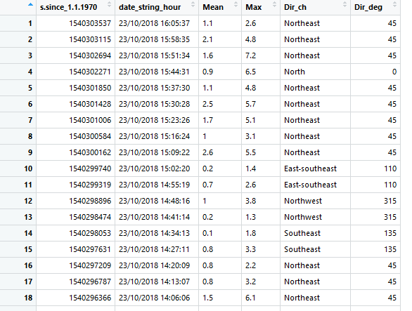

Para accceder a la información de la tabla lo haremos de la siguiente manera.

```r
#tabla[fila,columna]

tabla_1[1,1]
```

```
## [1] 1
## Levels: 1 10 2 3 4 5 6 7 8 9
```

Si dejo la información de fila o columna vacía, se entiende que queremos todas las filas o todas las columnas.

```r
#Queremos todas las filas de la columna 1

tabla_1[,1]
```

```
##  [1] 1  2  3  4  5  6  7  8  9  10
## Levels: 1 10 2 3 4 5 6 7 8 9
```

```r
#Queremos todas las columnas de la fila 1
tabla_1[1,]
```

```
##   Columna 1 Columna2
## 1         1        1
```

Una de las ventajas de nombrar las columnas es la siguiente. Normalmente tendremos una tabla con muchas variables (columnas) y queremos acceder a una variable concreta. Si sabemos en qué columna está mi variable podemos acceder a esta información como ya hemos visto poniendo el número de columna. Pero, si hemos nombrado la columna debidamente podemos acceder a la informacion de dicha columna utilizando el símbolo “$”. **Esto es muy útil**. *HAY QUE NOMBRAR LAS COLUMNAS.*

```r
tabla_1$`Columna 1`
```

```
##  [1] 1  2  3  4  5  6  7  8  9  10
## Levels: 1 10 2 3 4 5 6 7 8 9
```

# Moraleja

Este documento es el primero de unos cuantos que iré subiendo a nuestra carpeta compartida de github. Creo que es importante saber manejar y crear vectores y tablas para seguir avanzando en programación. Ya me comentaréis si preferís más nivel o vamos así, *poliki poliki*. Una vez ya estemos comodos trabajando con vectores y tablas pasaremos al siguiente nivel:

- Operaciones con vectores y tablas
- Operaciones lógicas
- Bucles, funciones if, while y for.

Pero eso más adelante.Un abrazzzzito.